# NHANES 2017–2020: Health Insurance and Blood-Sugar Screening

Exploratory covariate analysis and positivity check

Sujit Silas Armstrong

June 09, 2026

# 1. Causal estimand

We fix the causal question before any exploratory analysis so that covariate selection and filtering decisions are driven by the assumptions, not by the data.

- **Target population.** Non-institutionalized U.S. adults aged ≥ 20 years sampled in the NHANES **2017–March 2020 pre-pandemic** cycle (the `P_` files).
- **Treatment / exposure $A$.** Health-insurance coverage, `HIQ011` — *“Are you covered by health insurance or some other kind of health-care plan?”* Binarized as **Insured (1)** vs. **Uninsured (0)**.
- **Outcome $Y$.** `DIQ180` — *“Had blood tested for sugar/diabetes in the past three years?”* Binarized as **Screened (1)** vs. **Not screened (0)**.
- **Estimand.** The **average treatment effect (ATE)** on the probability of blood-sugar screening:
  $$\tau \;=\; \mathbb{E}\big[\,Y^{a=1} -
  Y^{a=0}\,\big]
  \;=\; \mathbb{E}\big[\,Y^{\text{insured}} -
  Y^{\text{uninsured}}\,\big].$$

**Identifying assumptions.** The ATE is identified from observational NHANES data under:

1. **Consistency** — observed $Y$ equals the potential outcome under the observed insurance status.
2. **Conditional exchangeability (no unmeasured confounding)** — $Y^a \perp A \mid L$ for the measured covariate set $L$ below.
3. **Positivity** — $0 < \Pr(A = a \mid L = l) < 1$ for every covariate stratum $l$ that occurs in the population. **This is the assumption the summary table in Section 6 is built to interrogate.**

**Measured confounders $L$.** Factors plausibly affecting *both* insurance coverage and the propensity to be screened:

- *Demographic / socioeconomic:* age, sex, race/ethnicity, education, family income-to-poverty ratio, marital status, U.S.-vs-foreign birth, interview language (acculturation proxy).
- *Health status / risk:* BMI, self-rated general health, prior hypertension diagnosis (a guideline risk factor that itself prompts diabetes screening).
- *Health behavior:* ever-smoking, ever-drinking alcohol.

# 2. Download the NHANES source files

The 2017–2020 pre-pandemic files are served as SAS transport (`.XPT`) files from the CDC. We download each once into a local `data/` cache and read with `haven::read_xpt()`.

```r
data_dir <- "data"
dir.create(data_dir, showWarnings = FALSE)

base_url <- "https://wwwn.cdc.gov/Nchs/Data/Nhanes/Public/2017/DataFiles/"

# component file -> the variables we keep from it
files <- c(
  P_DEMO = "P_DEMO.xpt",  # demographics: age, sex, race, education, income, lang
  P_HIQ  = "P_HIQ.xpt",   # health insurance questionnaire (treatment)
  P_DIQ  = "P_DIQ.xpt",   # diabetes questionnaire (outcome)
  P_BMX  = "P_BMX.xpt",   # body measures: BMI
  P_SMQ  = "P_SMQ.xpt",   # smoking: ever smoked >=100 cigarettes
  P_ALQ  = "P_ALQ.xpt",   # alcohol: ever had a drink
  P_HUQ  = "P_HUQ.xpt",   # health-care utilization: self-rated general health
  P_BPQ  = "P_BPQ.xpt"    # blood pressure: prior hypertension diagnosis
)

# imap() calls .f(value, name); `file` is the .xpt filename, `name` the label
read_nhanes <- function(file, name) {
  dest <- file.path(data_dir, file)
  if (!file.exists(dest)) {
    utils::download.file(paste0(base_url, file), dest, mode = "wb", quiet = TRUE)
  }
  haven::read_xpt(dest)
}

raw <- imap(files, read_nhanes)
map(raw, dim)
```

```
## $P_DEMO
## [1] 15560    29
##
## $P_HIQ
## [1] 15560    14
##
## $P_DIQ
## [1] 14986    28
##
## $P_BMX
## [1] 14300    22
##
## $P_SMQ
## [1] 11137    16
##
## $P_ALQ
## [1] 8965   10
##
## $P_HUQ
## [1] 15560     7
##
## $P_BPQ
## [1] 10195    11
```

# 3. Merge on the respondent ID (`SEQN`)

`SEQN` is the unique respondent sequence number that links every NHANES file. We keep all demographics records and left-join the questionnaire/exam files, so we start with the complete sampled population and *nothing is dropped yet*.

```r
demo <- raw$P_DEMO %>%
  select(SEQN, RIAGENDR, RIDAGEYR, RIDRETH3, DMDEDUC2, DMDMARTZ,
         DMDBORN4, INDFMPIR, SIALANG,
         # survey-design variables, carried for later weighted analysis
         SDMVPSU, SDMVSTRA, WTINTPRP, WTMECPRP)

hiq <- raw$P_HIQ %>% select(SEQN, HIQ011)
diq <- raw$P_DIQ %>% select(SEQN, DIQ180)
bmx <- raw$P_BMX %>% select(SEQN, BMXBMI)
smq <- raw$P_SMQ %>% select(SEQN, SMQ020)
alq <- raw$P_ALQ %>% select(SEQN, ALQ111)
huq <- raw$P_HUQ %>% select(SEQN, HUQ010)
bpq <- raw$P_BPQ %>% select(SEQN, BPQ020)

merged <- demo %>%
  left_join(hiq, by = "SEQN") %>%
  left_join(diq, by = "SEQN") %>%
  left_join(bmx, by = "SEQN") %>%
  left_join(smq, by = "SEQN") %>%
  left_join(alq, by = "SEQN") %>%
  left_join(huq, by = "SEQN") %>%
  left_join(bpq, by = "SEQN")

dim(merged)
```

```
## [1] 15560    20
```

# 4. Recode variables

NHANES uses numeric codes with `7`/`77`/`9`/`99` reserved for *Refused* and *Don’t know*; we map those to `NA`. Treatment and outcome are binarized as defined in the estimand.

```r
analytic_full <- merged %>%
  mutate(
    # ---- treatment: insurance coverage ----
    insured = case_when(
      HIQ011 == 1 ~ "Insured",
      HIQ011 == 2 ~ "Uninsured",
      TRUE        ~ NA_character_           # 7 = refused, 9 = don't know
    ),
    insured = factor(insured, levels = c("Uninsured", "Insured")),

    # ---- outcome: blood-sugar screening in past 3 years ----
    screened = case_when(
      DIQ180 == 1 ~ "Screened",
      DIQ180 == 2 ~ "Not screened",
      TRUE        ~ NA_character_           # 7/9 and missing
    ),
    screened = factor(screened, levels = c("Not screened", "Screened")),

    # ---- covariates ----
    age = RIDAGEYR,
    sex = factor(RIAGENDR, levels = c(1, 2), labels = c("Male", "Female")),
    race_eth = factor(RIDRETH3,
      levels = c(1, 2, 3, 4, 6, 7),
      labels = c("Mexican American", "Other Hispanic", "Non-Hispanic White",
                 "Non-Hispanic Black", "Non-Hispanic Asian", "Other/Multi")),
    education = factor(case_when(
      DMDEDUC2 %in% 1:2 ~ "< High school",
      DMDEDUC2 == 3     ~ "High school / GED",
      DMDEDUC2 == 4     ~ "Some college",
      DMDEDUC2 == 5     ~ "College graduate",
      TRUE              ~ NA_character_),
      levels = c("< High school", "High school / GED",
                 "Some college", "College graduate")),
    marital = factor(case_when(
      DMDMARTZ == 1 ~ "Married / partnered",
      DMDMARTZ == 2 ~ "Widowed / divorced / separated",
      DMDMARTZ == 3 ~ "Never married",
      TRUE          ~ NA_character_),
      levels = c("Married / partnered",
                 "Widowed / divorced / separated", "Never married")),
    us_born = factor(case_when(
      DMDBORN4 == 1 ~ "Born in U.S.",
      DMDBORN4 == 2 ~ "Born outside U.S.",
      TRUE          ~ NA_character_),
      levels = c("Born in U.S.", "Born outside U.S.")),
    interview_lang = factor(case_when(
      SIALANG == 1 ~ "English",
      SIALANG == 2 ~ "Spanish",
      TRUE         ~ NA_character_),
      levels = c("English", "Spanish")),
    pir = INDFMPIR,        # family income-to-poverty ratio (0–5, topcoded)
    bmi = BMXBMI,

    # ---- health status / risk ----
    gen_health = factor(case_when(
      HUQ010 == 1 ~ "Excellent",
      HUQ010 == 2 ~ "Very good",
      HUQ010 == 3 ~ "Good",
      HUQ010 == 4 ~ "Fair",
      HUQ010 == 5 ~ "Poor",
      TRUE        ~ NA_character_),         # 7/9 = refused / don't know
      levels = c("Excellent", "Very good", "Good", "Fair", "Poor")),
    hypertension = factor(case_when(
      BPQ020 == 1 ~ "Yes",
      BPQ020 == 2 ~ "No",
      TRUE        ~ NA_character_),
      levels = c("No", "Yes")),

    # ---- health behavior ----
    smoked_100 = factor(case_when(
      SMQ020 == 1 ~ "Yes",
      SMQ020 == 2 ~ "No",
      TRUE        ~ NA_character_),
      levels = c("No", "Yes")),
    alcohol_ever = factor(case_when(
      ALQ111 == 1 ~ "Yes",
      ALQ111 == 2 ~ "No",
      TRUE        ~ NA_character_),
      levels = c("No", "Yes"))
  )

# nice labels for the summary table
labelled::var_label(analytic_full) <- list(
  age       = "Age (years)",
  sex       = "Sex",
  race_eth  = "Race / ethnicity",
  education = "Education",
  marital   = "Marital status",
  us_born   = "Country of birth",
  interview_lang = "Interview language",
  pir       = "Income-to-poverty ratio",
  bmi       = "Body-mass index (kg/m²)",
  gen_health     = "Self-rated general health",
  hypertension   = "Ever told had high blood pressure",
  smoked_100     = "Ever smoked ≥100 cigarettes",
  alcohol_ever   = "Ever had an alcoholic drink",
  insured   = "Health-insurance coverage",
  screened  = "Blood-sugar screening (past 3 yr)"
)
```

# 5. Apply the assumption-driven filters

Only now do we restrict the sample, and *only* for reasons tied to the identifying assumptions:

1. **Target population** → adults aged ≥ 20 (the age group `DMDEDUC2` and the screening question are defined for).
2. **Consistency / well-defined treatment & outcome** → must have answered both the insurance and the screening question (non-missing $A$ and $Y$).

Covariate missingness is **not** used to drop rows here — we keep those records so the missingness itself can be inspected before any complete-case or imputation decision in the modeling stage.

```r
analytic <- analytic_full %>%
  filter(age >= 20,
         !is.na(insured),
         !is.na(screened))

# CONSORT-style accounting of what each restriction removes
flow <- tibble::tibble(
  step = c("Merged (all DEMO respondents)",
           "Aged >= 20",
           "+ non-missing insurance (A)",
           "+ non-missing screening (Y)  [analytic set]"),
  n = c(
    nrow(analytic_full),
    sum(analytic_full$age >= 20, na.rm = TRUE),
    sum(analytic_full$age >= 20 & !is.na(analytic_full$insured), na.rm = TRUE),
    nrow(analytic)
  )
)
flow
```

| step | n |
| --- | --- |
| Merged (all DEMO respondents) | 15560 |
| Aged >= 20 | 9232 |
| + non-missing insurance (A) | 9210 |
| + non-missing screening (Y) [analytic set] | 7550 |

```r
# write the analytic dataframe to CSV
out_csv <- "nhanes_insurance_screening_analytic.csv"
analytic_out <- analytic %>%
  select(SEQN, insured, screened,
         age, sex, race_eth, education, marital, us_born, interview_lang,
         pir, bmi, gen_health, hypertension, smoked_100, alcohol_ever,
         SDMVPSU, SDMVSTRA, WTINTPRP, WTMECPRP)
readr::write_csv(analytic_out, out_csv)
cat("Wrote", nrow(analytic_out), "rows to", out_csv, "\n")
```

```
## Wrote 7550 rows to nhanes_insurance_screening_analytic.csv
```

# 6. Positivity check — covariate distribution by treatment arm

For the ATE to be identified, every covariate stratum must contain both insured and uninsured respondents (positivity).

```r
tbl <- analytic %>%
  select(insured, age, sex, race_eth, education, marital, us_born,
         interview_lang, pir, bmi, gen_health, hypertension,
         smoked_100, alcohol_ever) %>%
  tbl_summary(
    by = insured,
    missing = "ifany",
    missing_text = "Missing",
    statistic = list(all_continuous()  ~ "{mean} ({sd})",
                     all_categorical() ~ "{n} ({p}%)"),
    digits = all_continuous() ~ 1
  ) %>%
  add_overall() %>%
  add_p() %>%                                  # association with treatment
  add_n() %>%
  modify_header(label ~ "**Covariate**") %>%
  modify_spanning_header(all_stat_cols() ~ "**Insurance status (treatment)**") %>%
  bold_labels()

tbl
```

| **Covariate** | **N** | **Insurance status (treatment)** **Overall** N = 7,550<sup>1</sup> | **Insurance status (treatment)** **Uninsured** N = 1,312<sup>1</sup> | **Insurance status (treatment)** **Insured** N = 6,238<sup>1</sup> | **p-value**<sup>2</sup> |  |
| --- | --- | --- | --- | --- | --- | --- |
| Age (years) | 7,550 | 48.8 (17.6) | 40.5 (13.9) | 50.6 (17.8) |  | <0.001 |
| Sex | 7,550 |  |  |  | <0.001 |  |
| Male |  | 3,589 (48%) | 724 (55%) | 2,865 (46%) |  |  |
| Female |  | 3,961 (52%) | 588 (45%) | 3,373 (54%) |  |  |
| Race / ethnicity | 7,550 |  |  |  | <0.001 |  |
| Mexican American |  | 853 (11%) | 297 (23%) | 556 (8.9%) |  |  |
| Other Hispanic |  | 772 (10%) | 190 (14%) | 582 (9.3%) |  |  |
| Non-Hispanic White |  | 2,615 (35%) | 280 (21%) | 2,335 (37%) |  |  |
| Non-Hispanic Black |  | 2,002 (27%) | 386 (29%) | 1,616 (26%) |  |  |
| Non-Hispanic Asian |  | 955 (13%) | 100 (7.6%) | 855 (14%) |  |  |
| Other/Multi |  | 353 (4.7%) | 59 (4.5%) | 294 (4.7%) |  |  |
| Education | 7,539 |  |  |  | <0.001 |  |
| < High school |  | 1,340 (18%) | 392 (30%) | 948 (15%) |  |  |
| High school / GED |  | 1,819 (24%) | 391 (30%) | 1,428 (23%) |  |  |
| Some college |  | 2,450 (32%) | 407 (31%) | 2,043 (33%) |  |  |
| College graduate |  | 1,930 (26%) | 119 (9.1%) | 1,811 (29%) |  |  |
| Missing |  | 11 | 3 | 8 |  |  |
| Marital status | 7,544 |  |  |  | <0.001 |  |
| Married / partnered |  | 4,346 (58%) | 698 (53%) | 3,648 (59%) |  |  |
| Widowed / divorced / separated |  | 1,605 (21%) | 240 (18%) | 1,365 (22%) |  |  |
| Never married |  | 1,593 (21%) | 374 (29%) | 1,219 (20%) |  |  |
| Missing |  | 6 | 0 | 6 |  |  |
| Country of birth | 7,547 |  |  |  | <0.001 |  |
| Born in U.S. |  | 5,355 (71%) | 788 (60%) | 4,567 (73%) |  |  |
| Born outside U.S. |  | 2,192 (29%) | 522 (40%) | 1,670 (27%) |  |  |
| Missing |  | 3 | 2 | 1 |  |  |
| Interview language | 7,550 |  |  |  | <0.001 |  |
| English |  | 6,796 (90%) | 980 (75%) | 5,816 (93%) |  |  |
| Spanish |  | 754 (10.0%) | 332 (25%) | 422 (6.8%) |  |  |
| Income-to-poverty ratio | 6,416 | 2.6 (1.6) | 1.7 (1.2) | 2.8 (1.6) | <0.001 |  |
| Missing |  | 1,134 | 255 | 879 |  |  |
| Body-mass index (kg/m²) | 6,858 | 29.6 (7.4) | 29.5 (7.6) | 29.6 (7.4) | 0.6 |  |
| Missing |  | 692 | 118 | 574 |  |  |
| Self-rated general health | 7,540 |  |  |  | <0.001 |  |
| Excellent |  | 983 (13%) | 151 (12%) | 832 (13%) |  |  |
| Very good |  | 2,232 (30%) | 325 (25%) | 1,907 (31%) |  |  |
| Good |  | 2,732 (36%) | 504 (39%) | 2,228 (36%) |  |  |
| Fair |  | 1,370 (18%) | 300 (23%) | 1,070 (17%) |  |  |
| Poor |  | 223 (3.0%) | 29 (2.2%) | 194 (3.1%) |  |  |
| Missing |  | 10 | 3 | 7 |  |  |
| Ever told had high blood pressure | 7,544 | 2,471 (33%) | 282 (22%) | 2,189 (35%) | <0.001 |  |
| Missing |  | 6 | 2 | 4 |  |  |
| Ever smoked ≥100 cigarettes | 7,547 | 3,046 (40%) | 586 (45%) | 2,460 (39%) | <0.001 |  |
| Missing |  | 3 | 0 | 3 |  |  |
| Ever had an alcoholic drink | 6,519 | 5,926 (91%) | 1,029 (91%) | 4,897 (91%) | >0.9 |  |
| Missing |  | 1,031 | 181 | 850 |  |  |

<sup>1</sup> Mean (SD); n (%)  
<sup>2</sup> Wilcoxon rank sum test; Pearson’s Chi-squared test

```r
# For completeness, the same distribution stratified by the OUTCOME.
analytic %>%
  select(screened, age, sex, race_eth, education, marital, us_born,
         interview_lang, pir, bmi, gen_health, hypertension,
         smoked_100, alcohol_ever) %>%
  tbl_summary(
    by = screened, missing = "ifany",
    statistic = list(all_continuous() ~ "{mean} ({sd})")
  ) %>%
  add_overall() %>%
  bold_labels()
```

| **Characteristic** | **Overall** N = 7,550<sup>1</sup> | **Not screened** N = 3,581<sup>1</sup> | **Screened** N = 3,969<sup>1</sup> |
| --- | --- | --- | --- |
| Age (years) | 49 (18) | 45 (18) | 52 (17) |
| Sex |  |  |  |
| Male | 3,589 (48%) | 1,860 (52%) | 1,729 (44%) |
| Female | 3,961 (52%) | 1,721 (48%) | 2,240 (56%) |
| Race / ethnicity |  |  |  |
| Mexican American | 853 (11%) | 427 (12%) | 426 (11%) |
| Other Hispanic | 772 (10%) | 332 (9.3%) | 440 (11%) |
| Non-Hispanic White | 2,615 (35%) | 1,208 (34%) | 1,407 (35%) |
| Non-Hispanic Black | 2,002 (27%) | 973 (27%) | 1,029 (26%) |
| Non-Hispanic Asian | 955 (13%) | 475 (13%) | 480 (12%) |
| Other/Multi | 353 (4.7%) | 166 (4.6%) | 187 (4.7%) |
| Education |  |  |  |
| < High school | 1,340 (18%) | 703 (20%) | 637 (16%) |
| High school / GED | 1,819 (24%) | 958 (27%) | 861 (22%) |
| Some college | 2,450 (32%) | 1,116 (31%) | 1,334 (34%) |
| College graduate | 1,930 (26%) | 801 (22%) | 1,129 (29%) |
| Unknown | 11 | 3 | 8 |
| Marital status |  |  |  |
| Married / partnered | 4,346 (58%) | 1,963 (55%) | 2,383 (60%) |
| Widowed / divorced / separated | 1,605 (21%) | 636 (18%) | 969 (24%) |
| Never married | 1,593 (21%) | 980 (27%) | 613 (15%) |
| Unknown | 6 | 2 | 4 |
| Country of birth |  |  |  |
| Born in U.S. | 5,355 (71%) | 2,559 (71%) | 2,796 (70%) |
| Born outside U.S. | 2,192 (29%) | 1,021 (29%) | 1,171 (30%) |
| Unknown | 3 | 1 | 2 |
| Interview language |  |  |  |
| English | 6,796 (90%) | 3,243 (91%) | 3,553 (90%) |
| Spanish | 754 (10.0%) | 338 (9.4%) | 416 (10%) |
| Income-to-poverty ratio | 2.63 (1.63) | 2.45 (1.62) | 2.79 (1.63) |
| Unknown | 1,134 | 562 | 572 |
| Body-mass index (kg/m²) | 30 (7) | 28 (7) | 31 (8) |
| Unknown | 692 | 358 | 334 |
| Self-rated general health |  |  |  |
| Excellent | 983 (13%) | 565 (16%) | 418 (11%) |
| Very good | 2,232 (30%) | 1,106 (31%) | 1,126 (28%) |
| Good | 2,732 (36%) | 1,237 (35%) | 1,495 (38%) |
| Fair | 1,370 (18%) | 580 (16%) | 790 (20%) |
| Poor | 223 (3.0%) | 87 (2.4%) | 136 (3.4%) |
| Unknown | 10 | 6 | 4 |
| Ever told had high blood pressure | 2,471 (33%) | 781 (22%) | 1,690 (43%) |
| Unknown | 6 | 3 | 3 |
| Ever smoked ≥100 cigarettes | 3,046 (40%) | 1,430 (40%) | 1,616 (41%) |
| Unknown | 3 | 2 | 1 |
| Ever had an alcoholic drink | 5,926 (91%) | 2,766 (91%) | 3,160 (91%) |
| Unknown | 1,031 | 529 | 502 |

<sup>1</sup> Mean (SD); n (%)

# 7. Exploratory covariate analysis

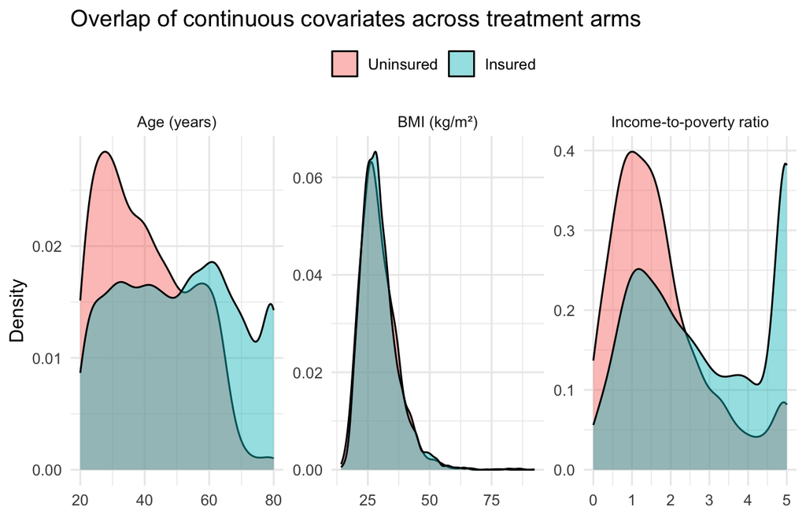

```r
# Standardized-mean-difference-style overlap: continuous covariates by arm
analytic %>%
  select(insured, age, pir, bmi) %>%
  pivot_longer(-insured, names_to = "covariate", values_to = "value") %>%
  ggplot(aes(value, fill = insured)) +
  geom_density(alpha = 0.45) +
  facet_wrap(~covariate, scales = "free", labeller = as_labeller(
    c(age = "Age (years)", pir = "Income-to-poverty ratio",
      bmi = "BMI (kg/m²)"))) +
  labs(title = "Overlap of continuous covariates across treatment arms",
       x = NULL, y = "Density", fill = NULL) +
  theme(legend.position = "top")
```

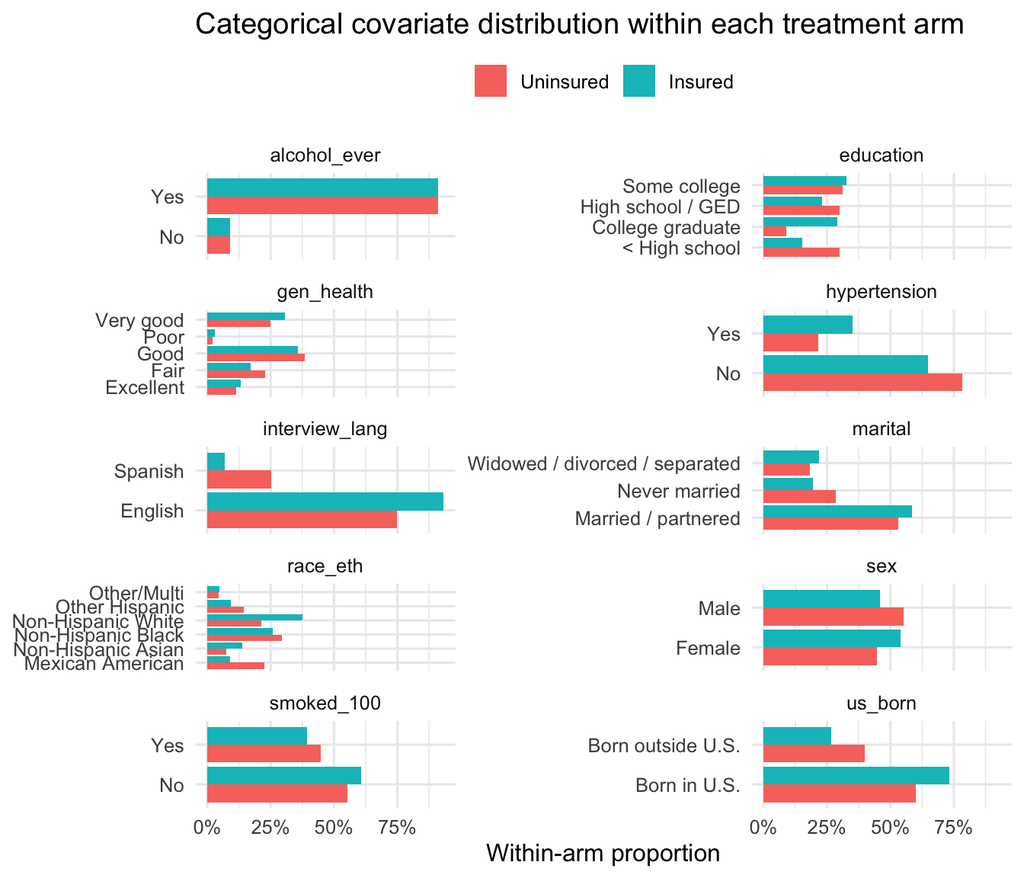

```r
# Categorical covariate composition within each treatment arm
analytic %>%
  select(insured, sex, race_eth, education, marital, us_born,
         interview_lang, gen_health, hypertension, smoked_100, alcohol_ever) %>%
  mutate(across(-insured, as.character)) %>%
  pivot_longer(-insured, names_to = "covariate", values_to = "level") %>%
  filter(!is.na(level)) %>%
  count(covariate, insured, level) %>%
  group_by(covariate, insured) %>%
  mutate(prop = n / sum(n)) %>%
  ungroup() %>%
  ggplot(aes(prop, level, fill = insured)) +
  geom_col(position = "dodge") +
  facet_wrap(~covariate, scales = "free_y", ncol = 2) +
  scale_x_continuous(labels = scales::percent) +
  labs(title = "Categorical covariate distribution within each treatment arm",
       x = "Within-arm proportion", y = NULL, fill = NULL) +
  theme(legend.position = "top")
```

```r
# Covariate missingness (informs complete-case vs imputation in modeling)
analytic %>%
  summarise(across(c(age, sex, race_eth, education, marital, us_born,
                     interview_lang, pir, bmi, gen_health, hypertension,
                     smoked_100, alcohol_ever),
                   ~ mean(is.na(.)))) %>%
  pivot_longer(everything(), names_to = "covariate",
               values_to = "pct_missing") %>%
  arrange(desc(pct_missing)) %>%
  mutate(pct_missing = scales::percent(pct_missing, accuracy = 0.1))
```

| covariate | pct_missing |
| --- | --- |
| pir | 15.0% |
| alcohol_ever | 13.7% |
| bmi | 9.2% |
| education | 0.1% |
| gen_health | 0.1% |
| marital | 0.1% |
| hypertension | 0.1% |
| us_born | 0.0% |
| smoked_100 | 0.0% |
| age | 0.0% |

[output cut: 3 more lines]

```r
# Crude (unadjusted) screening rate by insurance — the naive contrast
analytic %>%
  group_by(insured) %>%
  summarise(n = n(),
            screened_rate = mean(screened == "Screened"),
            .groups = "drop")
```

| insured | n | screened_rate |
| --- | --- | --- |
| Uninsured | 1312 | 0.3414634 |
| Insured | 6238 | 0.5644437 |